# Logistic Regression

Classification with Binary Response

Ranadeep Daw

2024-10-16

## Binary Response variables

- Continuous variable is a variable that can take any value within a given range.
  - e.g., height, weight, blood pressure, stock prices.
- We have done this case so far, where response variables are continuous.
- Today, we will extend to the case of binary response variables, e.g., variables with only two possible outcomes, e.g.,
  - Head/ Tail.
  - 1/ 0.
  - Yes/ No.

## From Linear Regression to Logistic Regression

- Linear Regression is a predictive model that estimates a continuous response variable based on one or more predictor variables.
- Logistic Regression is an extension of linear regression used when the outcome is binary (0/1, yes/no, etc.).
  - Since in logistic regression, we only work with two possible outcomes or classes, this is also known as **classification.**

## Classification Model

- One **binary** dependent variable/ response – $y$ . Possible values: 0, 1.
- $p$ independent variables/ predictors/ covariates – $X_1, X_2, \ldots, X_p$.
- $n$ observations from $\{y$, $X_1, X_2, \ldots, X_p\}$.

## How to model?

- With a binary variable, one calculates the following:
  $$\begin{align*}
  p_i = \mathbb{P}[y_i = 1 | \mathbf{X}] \\
  \Rightarrow 1 - p_i = \mathbb{P}[y_i = 0 | \mathbf{X}]
  \end{align*}$$
- The logistic regression model then takes the form:

$$p_i =
\frac{1}{1 + \exp^{-(\beta_0 + \beta_1 X_{1i} + \beta_2 X_{2i} + \ldots
+ \beta_p X_{pi})}}$$

## Different Versions

- The equivalent versions of the logistic regression model is:

$$\begin{align*}
\log\frac{p_i}{1 - p_i} = \beta_0 + \beta_1 X_{1i} + \beta_2 X_{2i} +
\ldots + \beta_p X_{pi}
\end{align*}$$

- We define the logit function as the $\text{logit}(p_i) = \log\frac{p_i}{1 - p_i}$. So, we can also write:

$$\begin{align*}
\text{logit}(p_i) = \beta_0 + \beta_1 X_{1i} + \beta_2 X_{2i} + \ldots +
\beta_p X_{pi}
\end{align*}$$

## Different Versions

- Sometimes you may find the notation $\mu_i= \beta_0 + \beta_1 X_{1i} + \beta_2 X_{2i} + \ldots + \beta_p X_{pi}$.
- Then, the model statement can be simplified as:
  $$\text{logit}(p_i) = \mu_i.$$
- You may also hear the term log-odds which is also the same thing as logit.

## Plotting

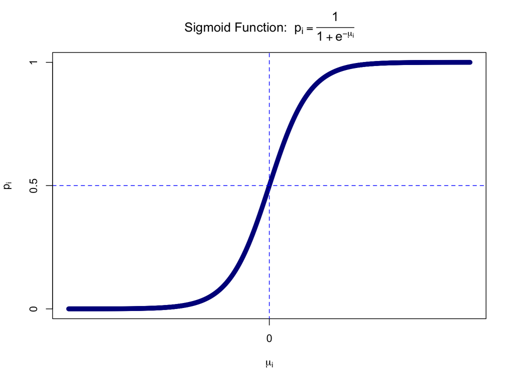

## Key Assumptions

- **Binary Outcome:** The dependent variable is binary (0/1, yes/no, head/tail, etc.).
- **Linearity in the Log-Odds:** The log-odds of the outcome is linearly related to the predictors.
- **No Multicollinearity:** Predictors should not be highly correlated with each other.

## Logistic Regression in $\texttt{R}$

- **Model Syntax:**

```r
<model_name> = glm( <y_column> ~ <X1_column> + <X2_column> +
                    ... + <Xp_column>, data = <data_name>,
                        family = binomial )
summary(<model_name>)
```

- **To predict the probability ($p_i$)**

```r
predict(<model_name>, type = "response")
```

## Example (cont.)

```r
data(mtcars)
logistic_model <- glm(am ~ mpg + disp + hp + drat,
                      data = mtcars,
                      family = "binomial")
summary(logistic_model)
```

```
##
## Call:
## glm(formula = am ~ mpg + disp + hp + drat, family = "binomial",
##     data = mtcars)
##
## Coefficients:
##              Estimate Std. Error z value Pr(>|z|)
## (Intercept) -86.98669   73.11741  -1.190    0.234
## mpg           1.22975    1.08227   1.136    0.256
## disp         -0.05933    0.07594  -0.781    0.435
## hp            0.15008    0.14239   1.054    0.292
## drat         13.80660   14.95907   0.923    0.356
##
## (Dispersion parameter for binomial family taken to be 1)
##
##     Null deviance: 43.2297  on 31  degrees of freedom
## Residual deviance:  7.7907  on 27  degrees of freedom
## AIC: 17.791
##
## Number of Fisher Scoring iterations: 10
```

## Example (Cont.)

```r
# Let's check the predicted probabilites (p_i)
predictions = predict(logistic_model, type="response")
predictions
```

```
##           Mazda RX4       Mazda RX4 Wag          Datsun 710      Hornet 4 Drive
##        4.252207e-01        4.252207e-01        8.527029e-01        4.371065e-08
##   Hornet Sportabout             Valiant          Duster 360           Merc 240D
##        1.684269e-07        3.046913e-11        6.289368e-05        4.346296e-03
##            Merc 230            Merc 280           Merc 280C          Merc 450SE
##        7.458122e-01        3.232749e-01        7.868022e-02        1.032652e-06
##          Merc 450SL         Merc 450SLC  Cadillac Fleetwood Lincoln Continental
##        3.123346e-06        2.360830e-07        2.220446e-16        8.402017e-13
##   Chrysler Imperial            Fiat 128         Honda Civic      Toyota Corolla
##        1.238914e-07        9.999995e-01        1.000000e+00        1.000000e+00
##       Toyota Corona    Dodge Challenger         AMC Javelin          Camaro Z28
##        1.159499e-01        4.282942e-12        1.481741e-09        4.184748e-02
##    Pontiac Firebird           Fiat X1-9       Porsche 914-2        Lotus Europa
##        1.104011e-08        9.997067e-01        9.999969e-01        9.999989e-01
##      Ford Pantera L        Ferrari Dino       Maserati Bora          Volvo 142E
##        9.999252e-01        9.924529e-01        9.999971e-01        9.948000e-01
```

## Plot: response against the predicted probabilites

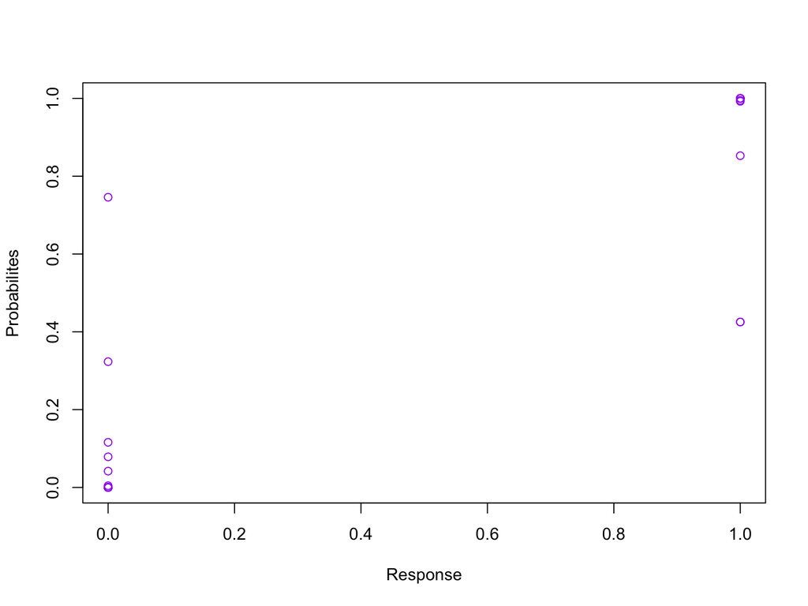

```r
AM = mtcars$am
predictions = predict(logistic_model, type="response")
plot(AM, predictions, col = "purple", xlab = "Response", ylab = "Probabilites")
```

## Comment

- As shown in the summary, this model performs poorly, with none of the variables being statistically significant.
- If I were to apply backward selection, I could still use the $\texttt{step}$ function here and perform model selection processes.
- We will revisit these types of situations involving categorical variable analysis and inference after Exam 2.

## Summary 1

- We learnt how to draw **scatteerplot**, and find covariance, correlation, and the correspomnding Spearman’s versions.
  - $\texttt{plot(x, y)}$.
  - $\texttt{cov(x, y), cor(x, y)}$.
  - $\texttt{cov(x, y, method="spearman")}$.
  - $\texttt{cor(x, y, method="spearman")}$.

## Summary 2

- We learnt linear regression – both simple and multiple linear regression.
  - $\texttt{<model>=lm(<y>~<x1>+<x2>+..., data=<data>)}$.
- Summary table: $\texttt{summary(<model>)}.$
- In the bottom 3 lines of summary, you will find the model-realted statistics: $\widehat{\sigma}$, $R^2$, adjusted $R^2$, and model significance test values such as $F$ statistic and $p$ value.
- In the coefficient table, you will find the details regarding coefficients estimates for $\hat{\beta}_1, \hat{\beta}_2, \ldots$. and their significance test results.

## Summary 3

- We learnt model selection by backward elimination:
  - Using $p$ values, keep dropping the least significant variable (only one at a time) until all the variables are significant.
  - Using the AIC values through $\texttt{R}$:
    - $\texttt{step(<model>, direction = "backward")}$
- Compare models using Adjusted $R^2$.

## Summary 4

- We learnt polynomial regression (only did the quadratic model):
  - $\texttt{<model>=lm(<y>~ poly(<x>, 2), data=<data>)}$.
- We did the logistic regression with binary data:
  - $\texttt{<model>= glm(<y>~ <x1>+<x2>...,}$ $\texttt{data=<data>, family = "binomial")}$.
  - Prediction: $\texttt{predict(<model>, type="response")}$.

## Extra Resource

Any topic you are interested in, Google with the keyword “bookdown”. Many instructors have uploaded their materials as a bookdown file and they usually contain $\texttt{R}$ implementations.